# Question 3: Portfolio Construction

The plot illustrates the cumulative returns of ALSI and SWIX over time. Although the ALSI exhibits some initial underperformance, it demonstrates a significant recovery and ultimately surpasses the SWIX, achieving notably higher returns in the long run.

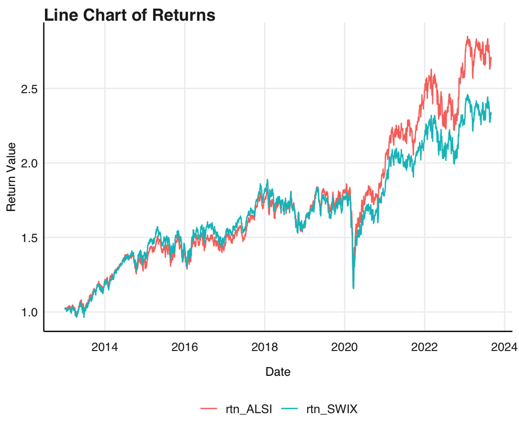

To determine whether capitalization impacts returns and whether it should be considered in further analysis, the rolling performance is examined. The plot, however, does not provide a definitive conclusion, suggesting that there are no significant long-term performance differences across varying capitalizations.

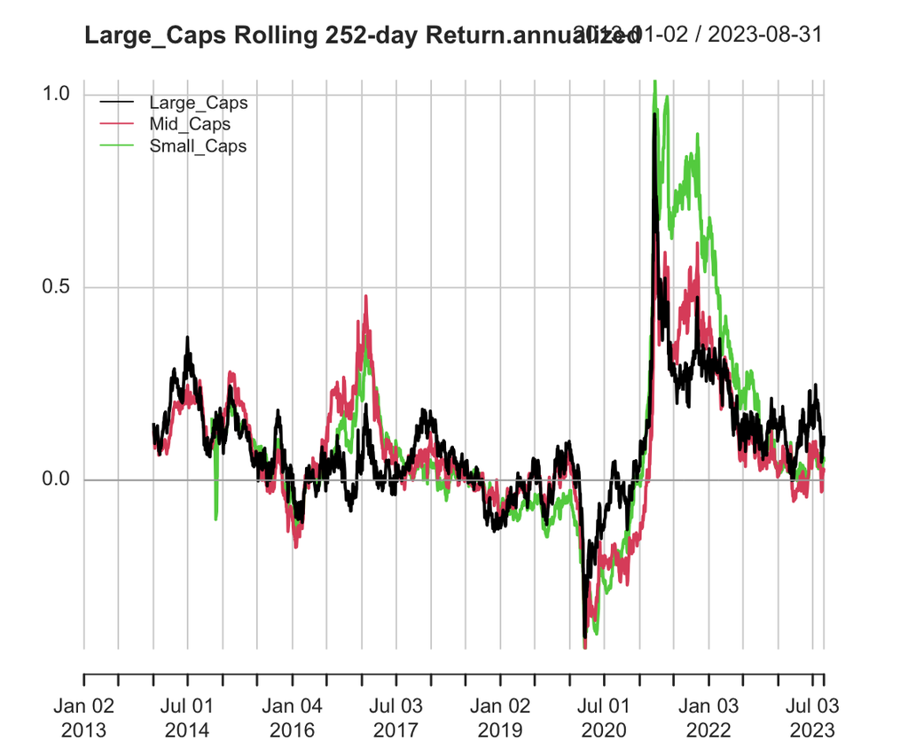

To gain deeper insight into the differences between the ALSI and the SWIX, their sector exposures should be analyzed. The analysis reveals a clear distinction between the two indexes, with the ALSI assigning a significantly higher weight to resources compared to the SWIX.

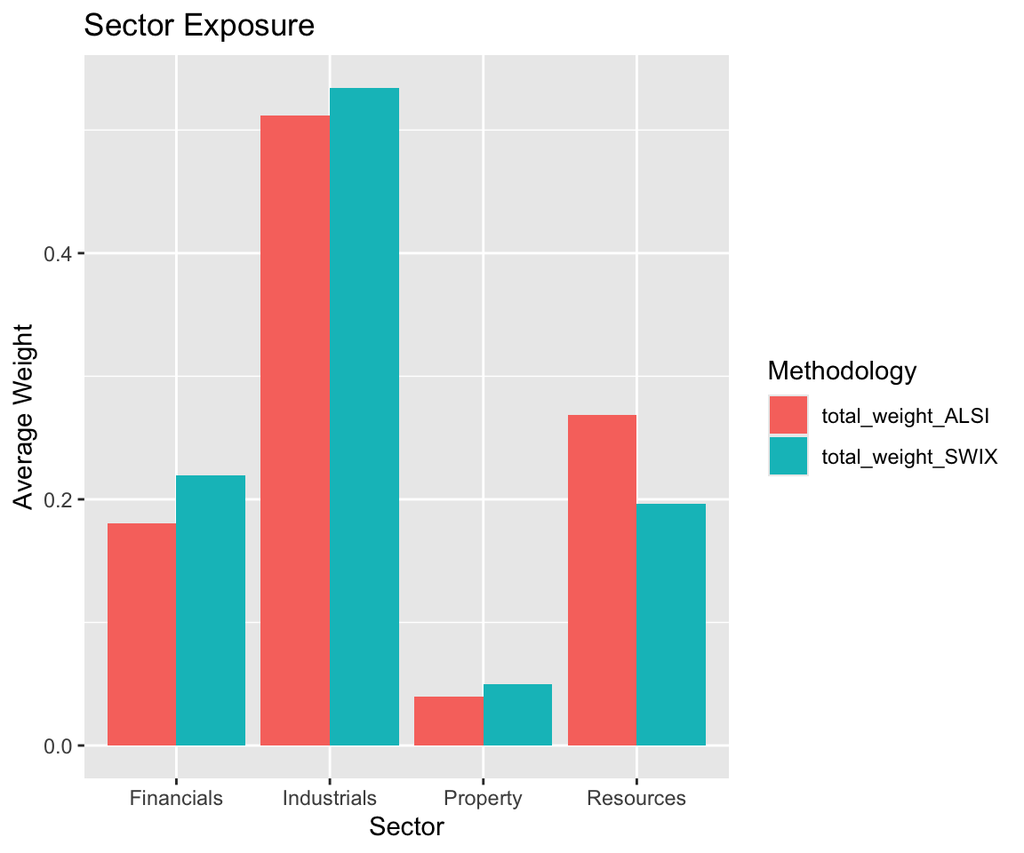

Another notable difference lies in stock concentration, with the top 10 stocks holding a significantly higher share in the ALSI compared to the SWIX.

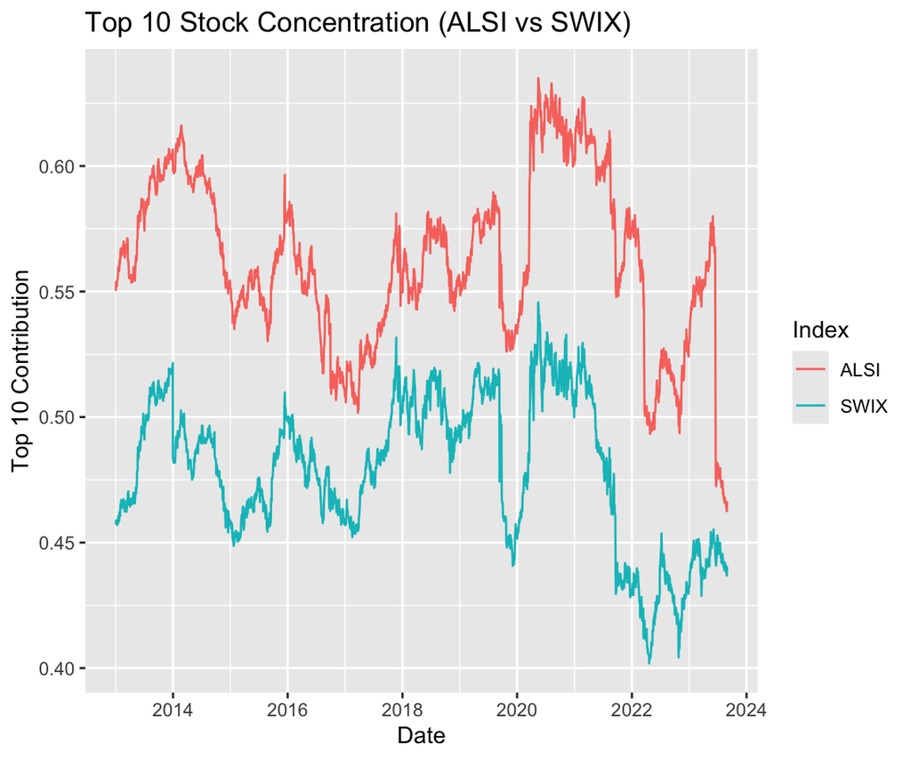

The Capped_funds function enables us to observe the impact of varying caps on different funds. The plot indicates that the return difference between ALSI and SWIX widens as caps increase. This suggests that the higher growth in the ALSI is driven by stocks with greater weight, aligning with the higher stock concentration observed in the previous analysis.

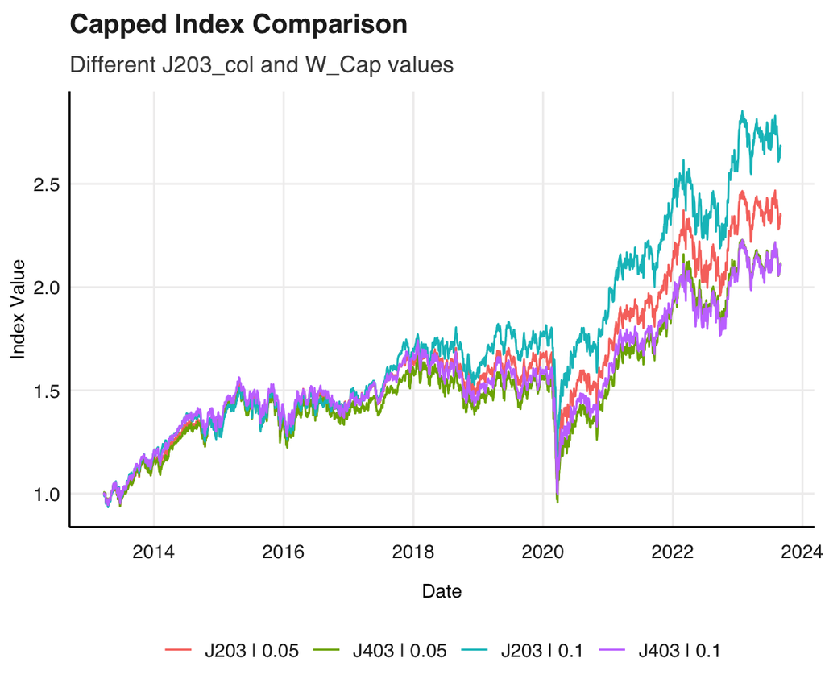